# Assignment 4a

Olaleye Damilare

9/17/2019

### Graphing U.S. States Data

1. Using the state data in R, create a data frame with the following variables:
- State – full name of the state
- Region – region
- Income – 1974 per capita income
- Life – life expectancy in years (1969-71)
- HS_Grad – percent high school graduates (1970)
- Illiteracy – illiteracy (1970, percent of population)

Construct the following graphs using the ggplot2 package.

**For each graph …**

- **add a title**
- **explain what you have learned from the graphical display**

```r
library(tidyverse)
```

```r
(us_states <- data.frame(State = state.name, Region = state.region, Income = state.x77[,2], Life = state.x77[,4], HS_Grad = state.x77[,6], Illiteracy = state.x77[,3]))
```

```
##                         State        Region Income  Life HS_Grad
## Alabama               Alabama         South   3624 69.05    41.3
## Alaska                 Alaska          West   6315 69.31    66.7
## Arizona               Arizona          West   4530 70.55    58.1
## Arkansas             Arkansas         South   3378 70.66    39.9
## California         California          West   5114 71.71    62.6
## Colorado             Colorado          West   4884 72.06    63.9
## Connecticut       Connecticut     Northeast   5348 72.48    56.0
## Delaware             Delaware         South   4809 70.06    54.6
## Florida               Florida         South   4815 70.66    52.6
## Georgia               Georgia         South   4091 68.54    40.6
## Hawaii                 Hawaii          West   4963 73.60    61.9
## Idaho                   Idaho          West   4119 71.87    59.5
## Illinois             Illinois North Central   5107 70.14    52.6
## Indiana               Indiana North Central   4458 70.88    52.9
## Iowa                     Iowa North Central   4628 72.56    59.0
## Kansas                 Kansas North Central   4669 72.58    59.9
## Kentucky             Kentucky         South   3712 70.10    38.5
## Louisiana           Louisiana         South   3545 68.76    42.2
## Maine                   Maine     Northeast   3694 70.39    54.7
## Maryland             Maryland         South   5299 70.22    52.3
## Massachusetts   Massachusetts     Northeast   4755 71.83    58.5
## Michigan             Michigan North Central   4751 70.63    52.8
## Minnesota           Minnesota North Central   4675 72.96    57.6
## Mississippi       Mississippi         South   3098 68.09    41.0
## Missouri             Missouri North Central   4254 70.69    48.8
## Montana               Montana          West   4347 70.56    59.2
## Nebraska             Nebraska North Central   4508 72.60    59.3
## Nevada                 Nevada          West   5149 69.03    65.2
## New Hampshire   New Hampshire     Northeast   4281 71.23    57.6
## New Jersey         New Jersey     Northeast   5237 70.93    52.5
## New Mexico         New Mexico          West   3601 70.32    55.2
## New York             New York     Northeast   4903 70.55    52.7
## North Carolina North Carolina         South   3875 69.21    38.5
## North Dakota     North Dakota North Central   5087 72.78    50.3
## Ohio                     Ohio North Central   4561 70.82    53.2
## Oklahoma             Oklahoma         South   3983 71.42    51.6
## Oregon                 Oregon          West   4660 72.13    60.0
## Pennsylvania     Pennsylvania     Northeast   4449 70.43    50.2
## Rhode Island     Rhode Island     Northeast   4558 71.90    46.4
```

[output cut: 47 more lines]

```
## Oklahoma              1.1
## Oregon                0.6
## Pennsylvania          1.0
## Rhode Island          1.3
## South Carolina        2.3
## South Dakota          0.5
## Tennessee             1.7
## Texas                 2.2
## Utah                  0.6
## Vermont               0.6
## Virginia              1.4
## Washington            0.6
## West Virginia         1.4
## Wisconsin             0.7
## Wyoming               0.6
```

2. Construct a graph of the distribution of the per capita income variable. Experiment with two different geoms. (Which one do you prefer and why?)

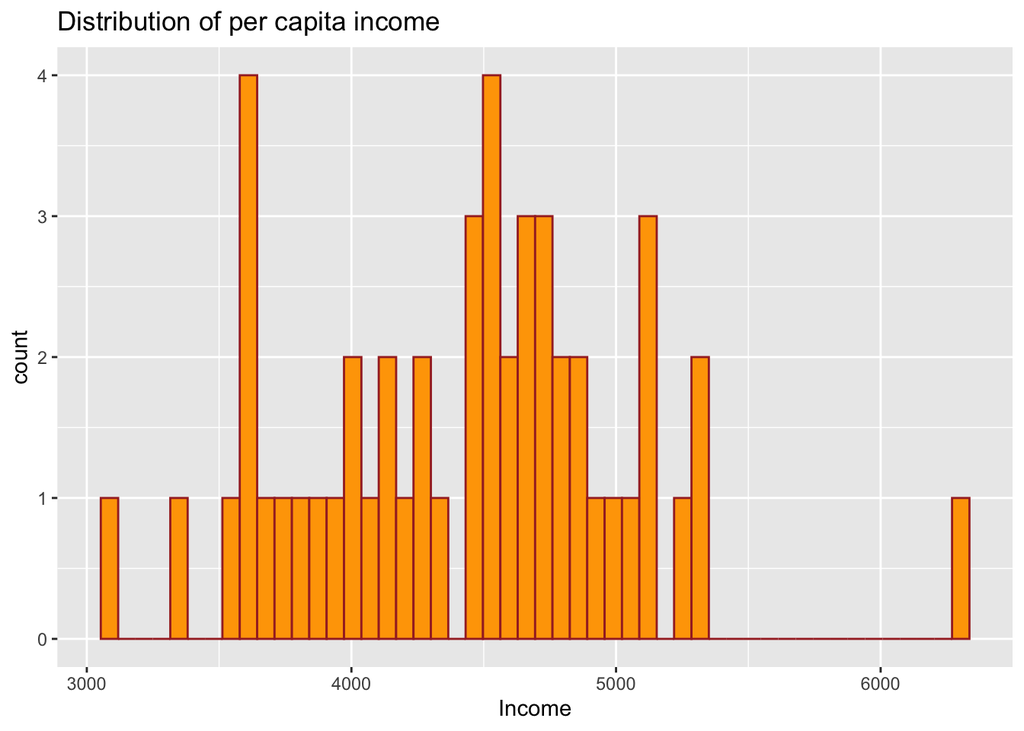

```r
ggplot(us_states, aes(Income)) + geom_histogram(color = "brown", fill = "orange", bins = 50) + ggtitle("Distribution of per capita income")
```

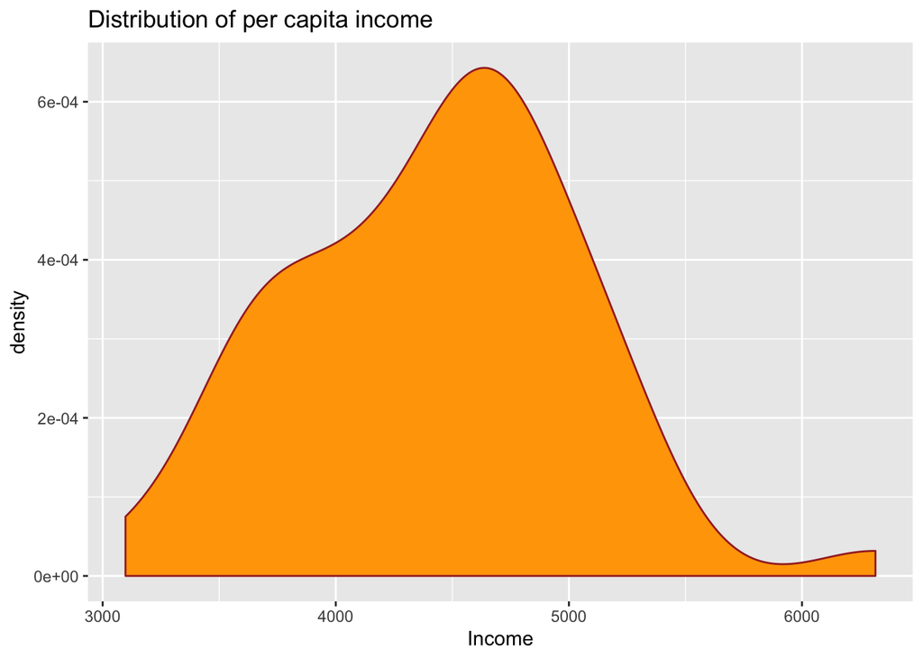

```r
ggplot(us_states, aes(Income)) + geom_density(color = "brown", fill = "orange") + ggtitle("Distribution of per capita income")
```

I prefer the histogram because it is easier to understand and it also gives a great estimate of the distribution compared to the density graph.

3. Compare per capita income of different regions graphically two ways. Have one graph use a single panel, and a second graph use different panels. (Again which way do you prefer and why?)

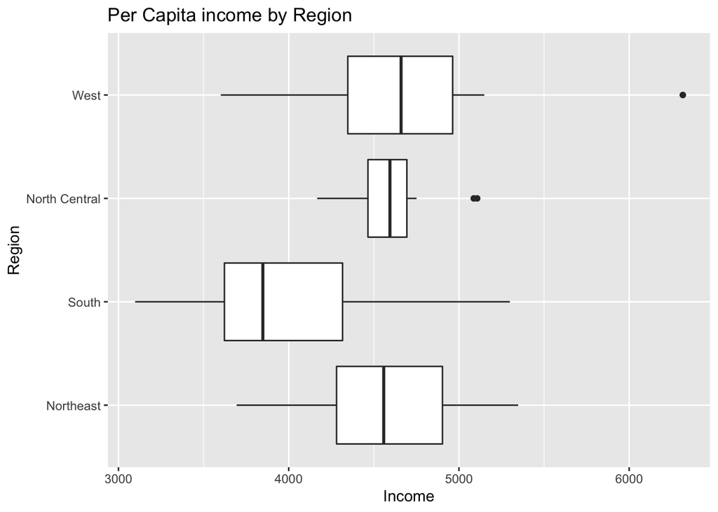

```r
ggplot(us_states) + geom_boxplot(mapping = aes(Region, Income)) + coord_flip() + ggtitle("Per Capita income by Region")
```

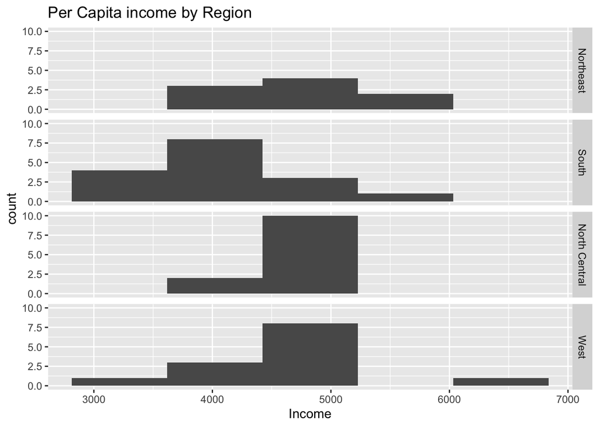

```r
ggplot(us_states) + geom_histogram(mapping = aes(Income), bins = 5) + facet_grid(Region ~ .) + ggtitle("Per Capita income by Region")
```

I prefer the first boxplot graph because everything is in one graph and it is easier to understand.

4. Construct a scatterplot of Illiteracy and HS_Grad where you indicate region by a different plotting point. Try using different colors and different point shapes.

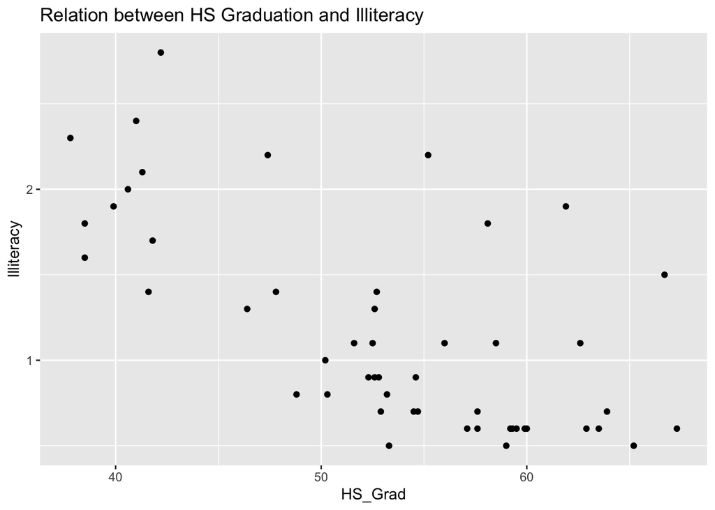

```r
ggplot(us_states) + geom_point(mapping = aes(HS_Grad, Illiteracy)) + ggtitle("Relation between HS Graduation and Illiteracy")
```

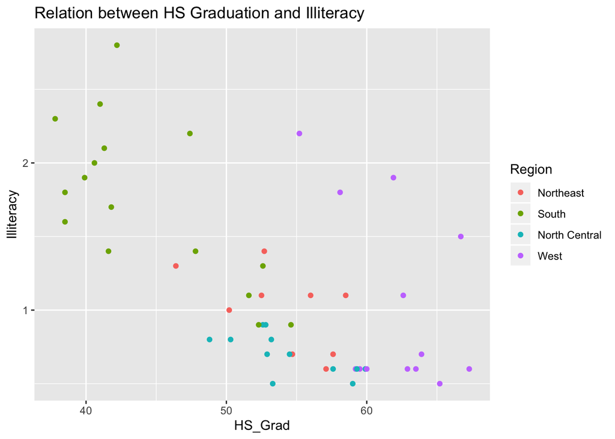

```r
ggplot(us_states) + geom_point(mapping = aes(HS_Grad, Illiteracy, color = Region)) + ggtitle("Relation between HS Graduation and Illiteracy")
```

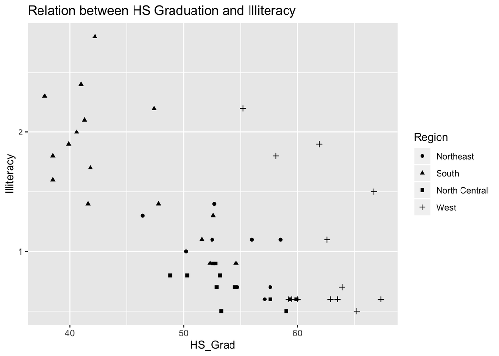

```r
ggplot(us_states) + geom_point(mapping = aes(HS_Grad, Illiteracy, shape = Region)) + ggtitle("Relation between HS Graduation and Illiteracy")
```

5. Create a new categorical variable CLife which divides the states into low life expectancy and high life expectancy. Using different panels, compare scatterplots of Illiteracy and HS_Grad for the two life expectancy groups.

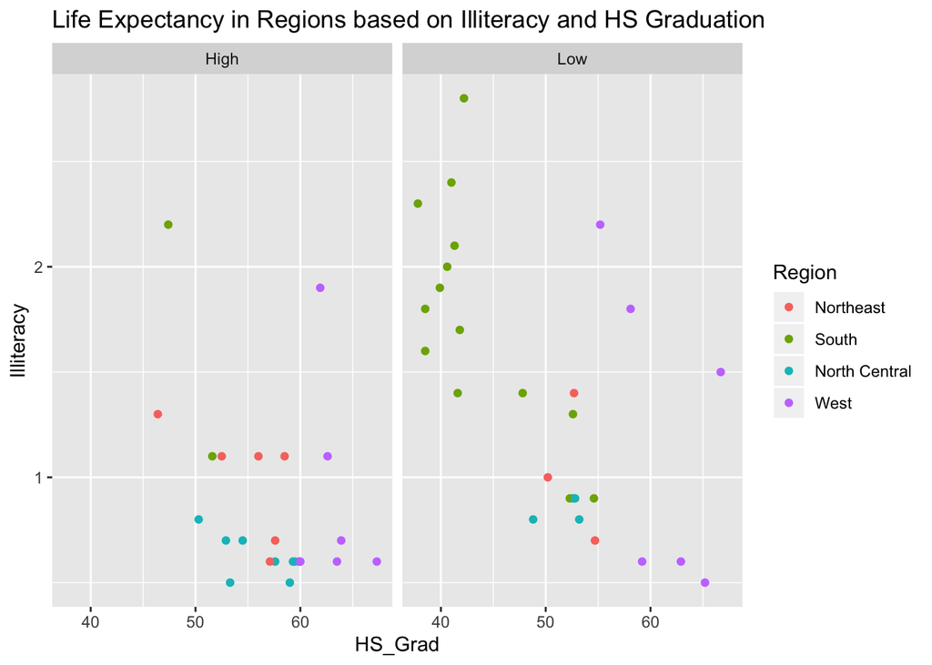

```r
us_states$CLife <- ifelse(us_states$Life > mean(us_states$Life), "High", "Low")
ggplot(us_states) + geom_point(mapping = aes(HS_Grad, Illiteracy, color = Region)) + facet_grid(. ~ CLife) + ggtitle("Life Expectancy in Regions based on Illiteracy and HS Graduation")
```

Clearly, in the 70s a majority of the southern states had poor High School graduation rates which might have factored towards low life expectancy as well.

6. Redo the second graph in question 4 where you use state abbreviations as the plotting symbol.

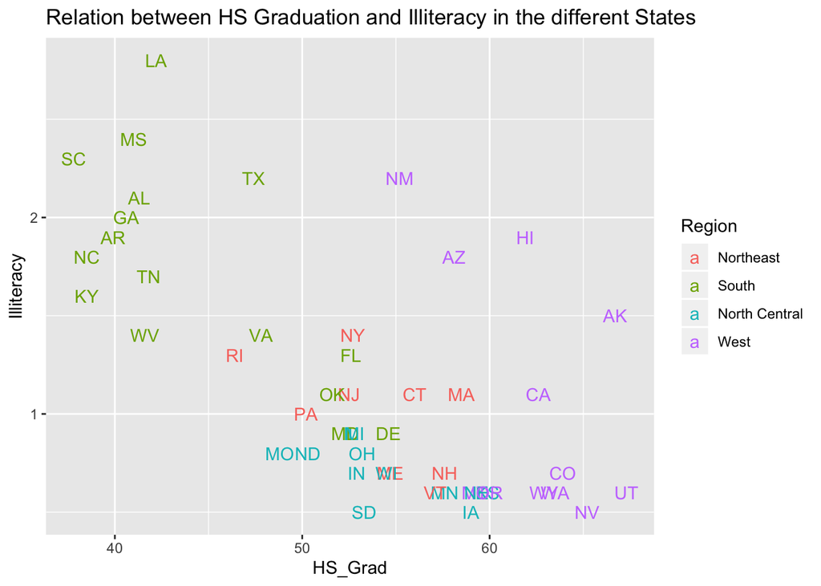

```r
ggplot(us_states, mapping = aes(HS_Grad, Illiteracy, label = state.abb, color = Region)) + geom_text() + ggtitle("Relation between HS Graduation and Illiteracy in the different States")
```